# Mixed Model on Polimi Students Data

07/07/2020

## Target

**Apply Multilevel Model on PoliMI data to maximise performance on dropout prediction.**

Students are rarely indipendent, they are clustered or nested in a way that makes the observations not truly independent.

## Agenda

1. Data Preparation
- Data Exploration
- Data Cleaning
- Data Aggregation
- Feature Selection
- Missing Values
1. Models
- Data Partition
- Model Creation
- Results Evaluation

## Careers

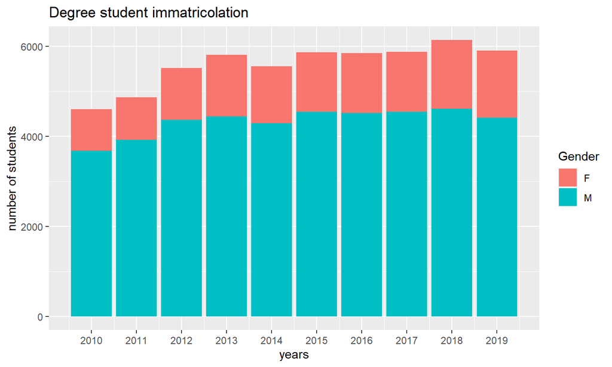

## Career Description

- personal data
- previous studies
- admission score
- degree course
- exams
- degree / dropout

## Ended careers by course

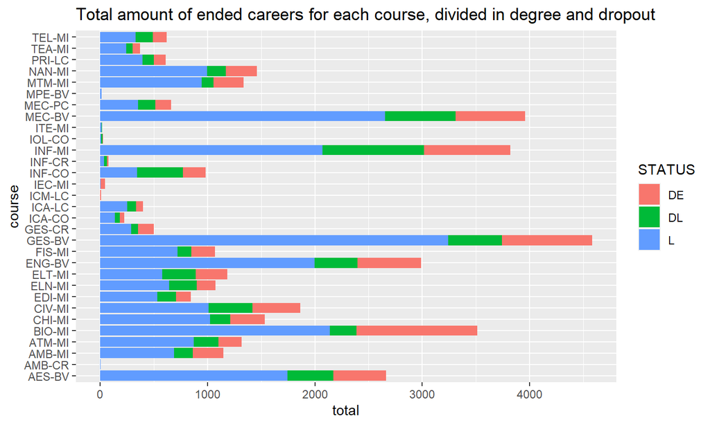

## Previous Studies

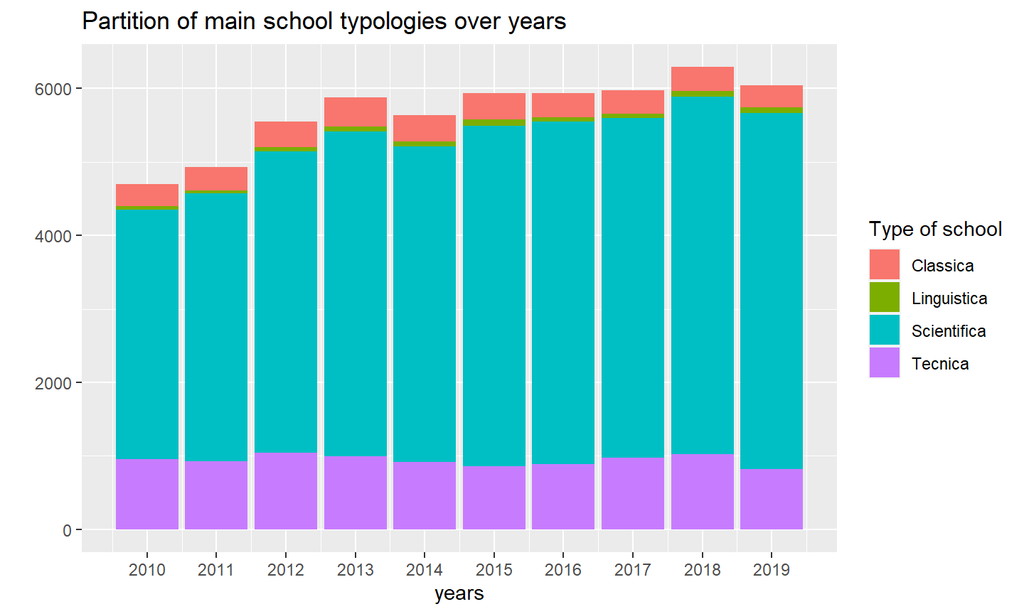

## Foreign Previous Studies

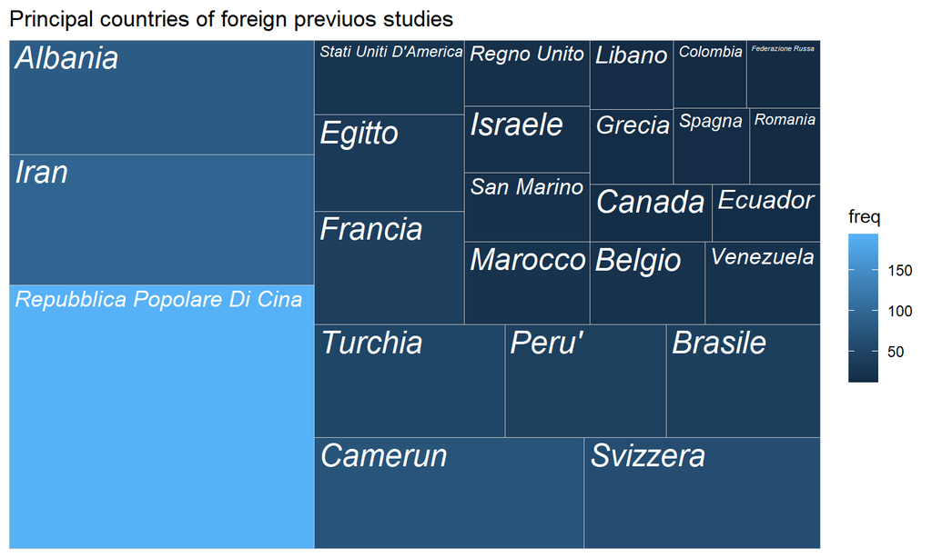

## Admission Test - score distribution

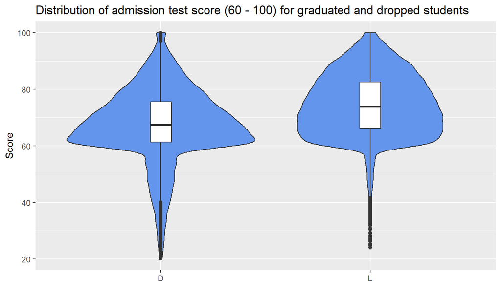

## Data Cleaning

- We focus only on young students (less than 30 years old) because of data distribution. Older people have different paces and different ways to handle the studies, so they cannot be used to predict majority.
- We remove also maximum value for school grade different than 100 means that those people are outlier (for example, 60 as maximum grade was used in the past)

## Admission test - partial values

- The admission test if composed on 4 sections:
  - math
  - physics
  - reading comprehension
  - english
- each session has a different score and different importance, we normalized the value by mean

```
##  CV_NOR_YY ENG_NOR_YY FIS_NOR_YY MAT_NOR_YY
##  0.7829635  0.8331675  0.5997384  0.7056361
```

## Admission test - Math score

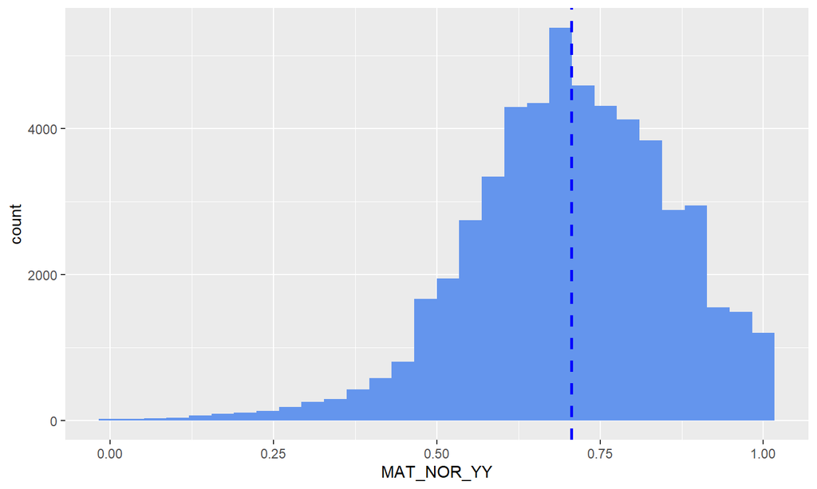

## Admission test - Physics score

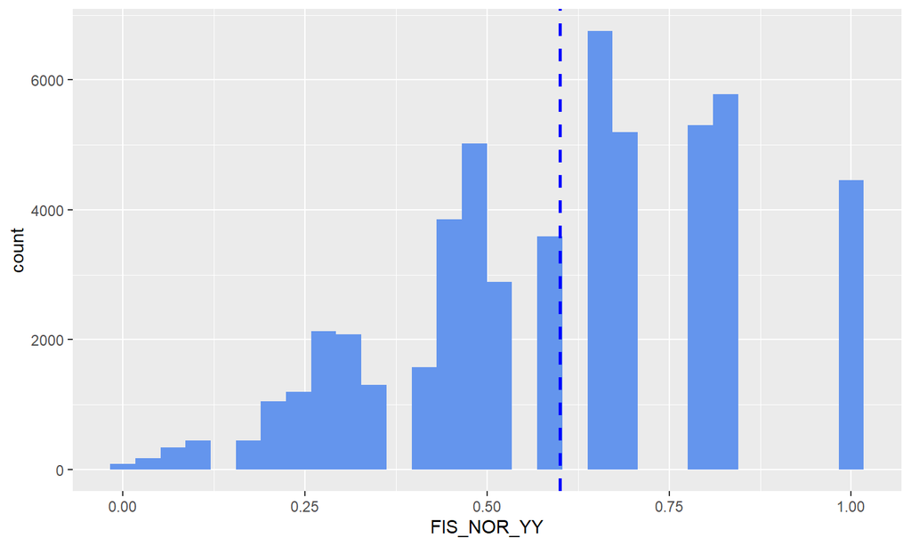

## Admission test - Reading comprehension score

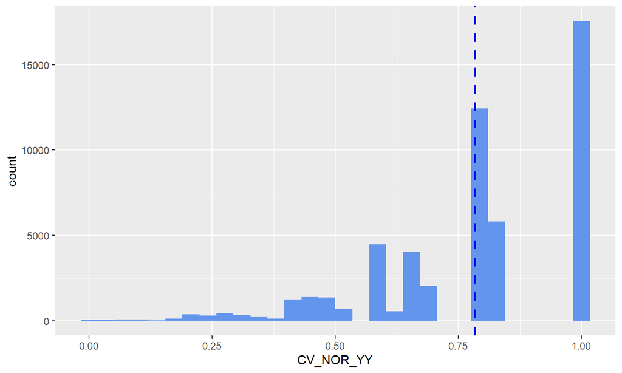

## Admission test - English

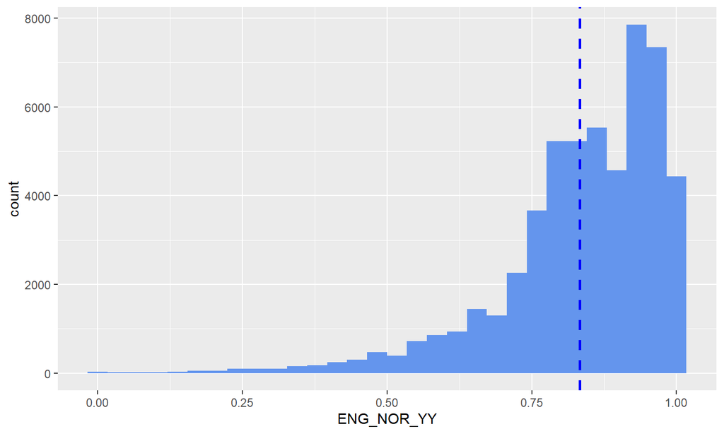

## Admission test by gender

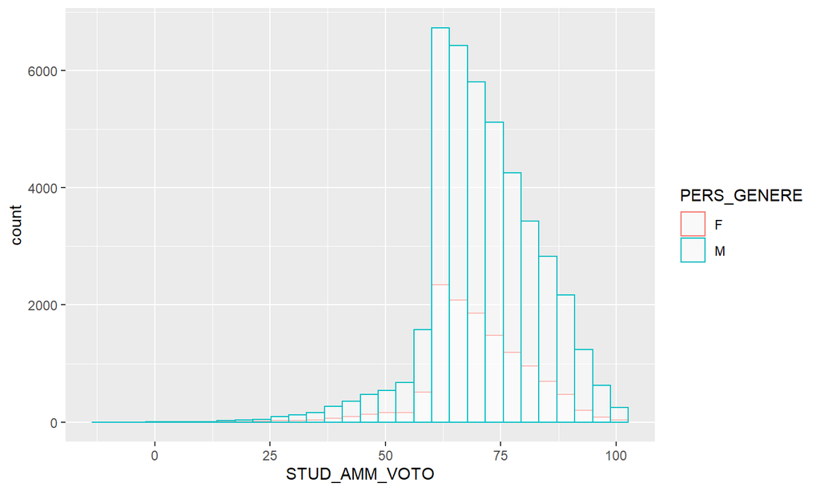

## Admission test and Previous studies

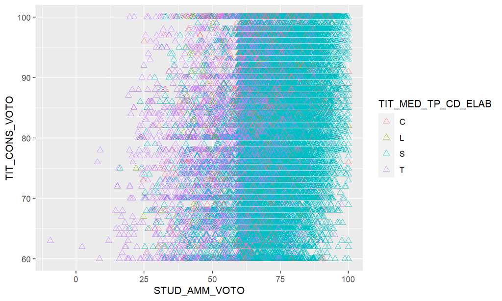

## Exams

- The information are aggregate by year and only few features remain in the dataset:
  - number of passed exams (CFU)
  - number of failed exams (CFU)
  - avarage exams

## Data Cleaning

[figure not shown]

## Reduce Columns

Only few column were indipendent and significant, so we reduce the dataset for a smaller model